# CHDH SNA 3

[Johan Koskinen](https://psychologicalsciences.unimelb.edu.au/research/msps-research-groups/Social_Networks_Laboratory)

2026-03-19

# Overview

This session is about the basics of stochastic actor-oriented models (SAOMs). We refer to the RSiena page https://www.stats.ox.ac.uk/~snijders/siena/ for further resources. Here we will

- Introduce SAOM as a simulation model
- Present the basic functions and functionalities
- Briefly discuss an empirical example

It is appropriate that we **simulate** the model as Siena stands for

> **S**imulation **I**nvestigation for **E**mpirical **N**etwork **A**nalysis

# Packages

We will use functionality from the network packages `sna` and `network` (see https://raw.githubusercontent.com/johankoskinen/CHDH-SNA/main/Markdowns/CHDH-SNA-2.Rmd). The main packages for SAOM is `RSiena`.

First time you use them, install the packages (*uncomment the install commmands*)

```r
# install.packages("sna")
# install.packages("network")
# If you have not yet installed RSiena, install it:
# install.packages("RSiena", repos="https://cloud.r-project.org")
# (if you do not specify the repos,
#  you get a choice from a list of available repositories.)
# This installation will persist on your machine, no need to repeat it later.
# To install the recent version from GitHub go to
# https://github.com/snlab-nl/rsiena/releases/
```

Once packages are installed, load them

```r
library("sna")
library("network")
library('RSiena')
```

# Data set

The RSiena package automatically loads the van de Bunt’s Freshman dataset (see [Data description](https://www.stats.ox.ac.uk/~snijders/siena/vdBunt_data.htm)). We will use time-point 3 and 4

```r
?tmp3# opens the helpfile with information about the dataset
class(tmp3)# both time-points are regular adjacency matrices
class(tmp4)
dim(tmp3)# 32 students by 32
n <- dim(tmp4)[1]
```

## Data checking

The original tie-variables had 6 levels but have here been dichotomised. It is good practice to check that ties are binary

```r
table(tmp3,useNA = 'always')
table(tmp4,useNA = 'always')
```

## Missing

RSiena handles missing data in estimation, but for the purposes of simulating and investigating the network, replace missing values

```r
tmp3[is.na(tmp3)] <- 0 # remove missing
tmp4[is.na(tmp4)] <- 0 # remove missing
```

## Plot change

Plotting the networks with nodes in the same places illustrates what the SAOM will try to model

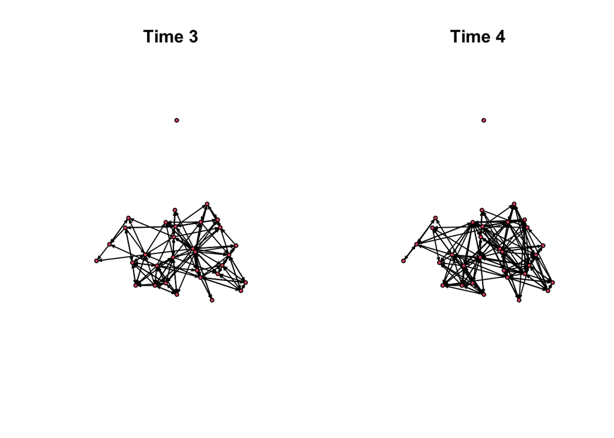

```r
par(mfrow = c(1,2))
coordin <- plot(as.network(tmp3), main='Time 3')
plot(as.network(tmp4),coord=coordin, main='Time 4')
```

> Looking closely we see that some arcs have been added and others been removed

In this session, we will assume that we have one initial network $X(t_0)=x_{obs}(t_0)$, at time $t_0$ and that we want to say something about a network $X(t_1)$, at time $t_1$, $t_0<t_1$.

> We will only use two **waves** but because of the Markov property of the model, all ingredients extend without limitations to several waves.

# Format data

To simulate (but also estimate) we need to execute, in turn, each of the functions

1. `sienaDependent` - formats class `matrix` to class `sienaDependent`
2. `sienaDataCreate` - formats data to class `siena`
3. `getEffects` - provides us with the *effects* we can use for the process
4. `sienaAlgorithmCreate` - sets up simulation/estimation settings

After these steps, the model is simulated/estimated using `siena07`

## sienaDependent

The function `sienaDependent` formats and translates the two **adjacency matrices** to a “sienaDependent” object:

```r
mynet1 <- sienaDependent(array(c(tmp3, tmp4), # the matrices in order
                               dim=c(32, 32,2))# are set as two slices in an array
                         )
```

For networks, `sienaDependent` takes networks clued together in an $n \times n \times$ number of waves, array.

> You can define, as dependent variables, one-mode networks, two-mode networks, or dependent mondadic variables

## sienaDataCreate

Once you have defined your variables, these are combined into a `siena` object using `sienaDataCreate`

```r
mydata <- sienaDataCreate(mynet1)
```

The siena object adds all relevant information about the data

```r
mydata
```

```
## Dependent variables:  mynet1
## Number of observations: 2
##
## Nodeset                  Actors
## Number of nodes              32
##
## Dependent variable mynet1
## Type               oneMode
## Observations       2
## Nodeset            Actors
## Densities          0.15 0.18
```

# Simulate

## getEffects

To determined what effects are available for our combination of different types of data

```r
myeff <- getEffects(mydata)
```

Assume a model where an actor $i$, when they make a change, only cares about how many ties they have.

```r
myeff <- includeEffects(myeff, recip,include=FALSE)# remove reciprocity which is DEFAULT
```

```
##   effectNumber effectName  shortName include fix   test  initialValue parm
## 1 14           reciprocity recip     FALSE   FALSE FALSE          0   0
```

```r
myeff$initialValue[myeff$shortName=='Rate'] <- 5.7288
myeff$initialValue[myeff$shortName=='density'][1] <- -0.7349
```

> For later reference, notice how `myeff` is on the right-hand side of the allocation of `includeEffects`

### Waiting times

What does the rate $\lambda = 5.7288$ mean?

Each time the network has changed (or an oppotunity to change), each actor waits $T_i \overset{i.i.d.}{\thicksim} Exp(\lambda)$ time.

> The actor that *gets to change* is the one who waits for the shortest amount of time

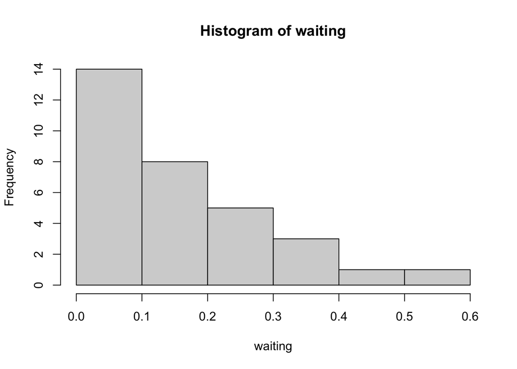

```r
waiting <- rexp(32, 5.7288)
hist(waiting)
```

```r
winner <- which( waiting == min(waiting))
paste('The winner is actor: ', winner)
```

```
## [1] "The winner is actor:  1"
```

### Micro-step

In the example of $i=1$, deciding between creating a tie to $j=2,4$ or breaking the tie to $j=3$

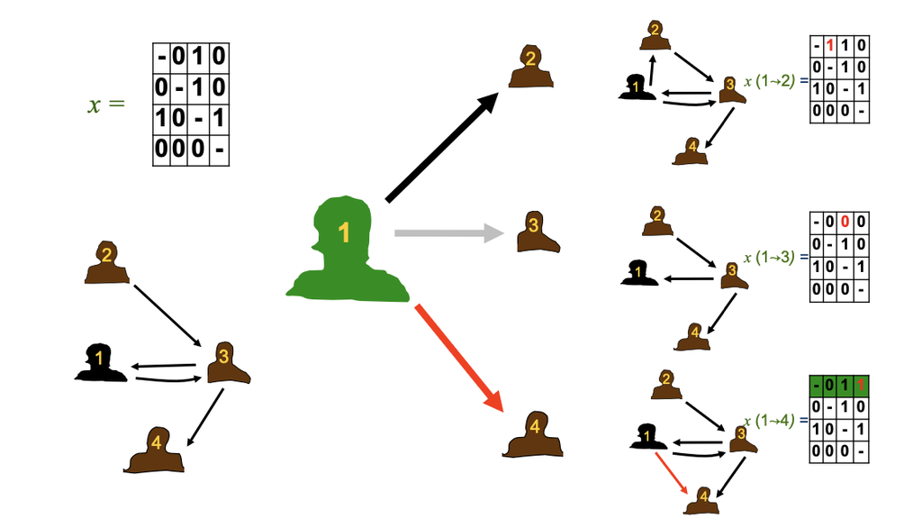

Micro-step

With our current model

$$\Pr(X(1\leadsto 2)=\Pr(X(1\leadsto
4)=\frac{e^{\beta_1(1-2x_{12})}}{1+\sum_{j\neq i}
e^{\beta(1-2x_{ij})}}=\frac{\exp(-0.7349)}{\exp(-0.7349)+\exp(0.7349)+\exp(-0.7349)+1}$$
and

$$\Pr(X(1\leadsto 3)=\frac{e^{\beta_1(1-2x_{13})}}{1+\sum_{j\neq i}
e^{\beta(1-2x_{ij})}}=\frac{\exp(0.7349)}{\exp(-0.7349)+\exp(0.7349)+\exp(-0.7349)+1}$$
The conditional probability of $i=1$ **creating** the tie to $j=2$ is thus

```r
exp(-0.7349)/(exp(-0.7349)+exp(0.7349)+exp(-0.7349)+1)
```

```
## [1] 0.1185728
```

and the conditional probability of $i=1$ **deleting** the tie to $j=3$ is thus

```r
exp(0.7349)/(exp(-0.7349)+exp(0.7349)+exp(-0.7349)+1)
```

## sienaAlgorithmCreate

The function `sienaAlgorithmCreate` determines the simulation/estimation settings. Here we are going to

- Simulate `simOnly = TRUE`
- a total of `n3 = 100`

Networks, starting in $X(t_3)$

```r
sim_model  <-  sienaAlgorithmCreate(
                          projname = 'sim_model',# name will be appended to output
                          cond = FALSE, # NOT conditioning on num. changes
                          useStdInits = FALSE,# we are changing some defaults
                          nsub = 0 ,# more about subphases in estimation
                          n3 = 100,# number of simulations (in Phase 3)
                          simOnly = TRUE)# we only want to simulate
```

We are ready to simulate!

## siena07

The function `siena07` is the main engine of RSiena and is used to estimate *all models* (apart from hierarchical SAOMS)

```r
sim_ans <- siena07( sim_model,# the name of our model
                    data = mydata,# all of our data - see above for what is in there
                    effects = myeff,# the effects we have chosen, including parameters
                    returnDeps = TRUE,# save simulated networks
                    batch=TRUE )# batch=FALSE opens a GUI
```

## Read in a function

The networks are in `sim_ans$sims` but to help with extracting and formatting them we read in the function `reshapeRSienaDeps`

```r
source("https://raw.githubusercontent.com/johankoskinen/CHDH-SNA/main/data/reshapeRSienaDeps.R")
```

We apply it on `sim_ans`

```r
mySimNets <- reshapeRSienaDeps(sim_ans,n)# n is the number of nodes (defined above)
```

## Plot simulated networks

Plot networks with the same layout as for $X(t_3)$ above

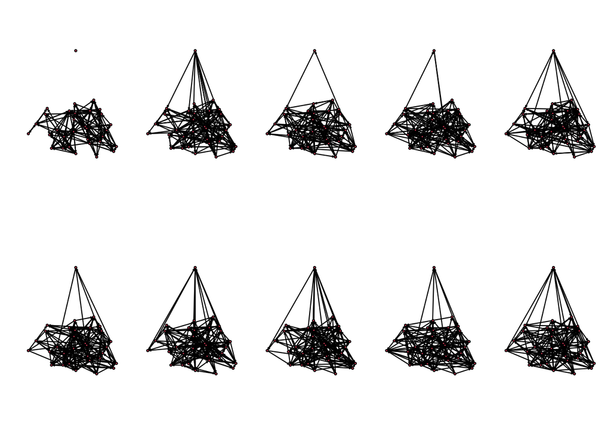

```r
par(mfrow=c(2,5),# want 2 by 5 panels
    oma = c(0,1,0,0) + 0.1,# custom outer margins
    mar = c(1,0,0,0) + 0.1)# custom inner margins
plot(as.network(tmp4),# observed network at t4
     coord=coordin) # observed network
invisible(# need to supress printing to consol
  apply(mySimNets[1:9,,],# for the first 9 networks in array
      1,# along first dimenstion, apply the following function
      function(x)
        plot(as.network(x),coord=coordin) ) )
```

It is hard to spot any differences. Plot density of the networks

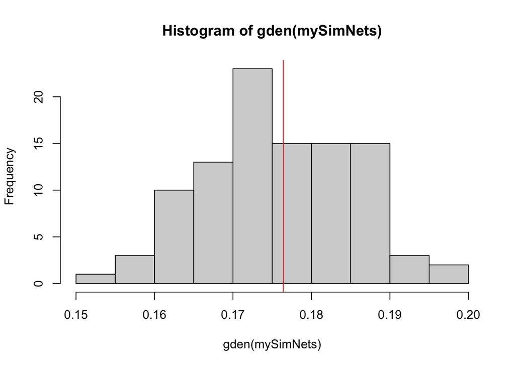

```r
hist( gden(mySimNets ) )
abline( v = gden(tmp4), col='red')
```

> If actors only care about how many ties they have, we predict the density at $t_4$ correctly

How about the number of **reciprocated ties** $x_{ij}x_{ji}=1$

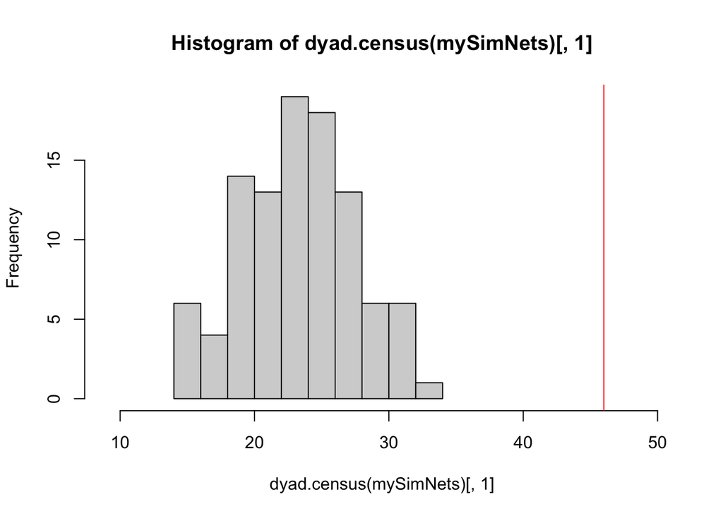

```r
hist( dyad.census(mySimNets)[,1] ,xlim=c(9,50))
abline(v = dyad.census(tmp4)[1], col='red')
```

> Clearly, if the only rule actors have is to care about the number of ties they have, this is not enough to explain why there are so many (46) reciprocal dyads

# Reciprocity model

Simulate assuming that actors want to have reciprocated ties to others with the model with probabilities $\Pr(X(i \leadsto j) |i \text{ makes decision})$:
$$p_{ij}(X,\beta)=\frac{e^{\beta_d (1-2x_{ij}) +\beta_r (1-2x_{ij})x_{ji}
} }{ \sum_h e^{\beta_d (1-2x_{ih}) +\beta_r (1-2x_{ih})x_{hj} } }$$

```r
myeff <- includeEffects(myeff, recip,include=TRUE)# reinstate reciprocity which is DEFAULT
```

```
##   effectNumber effectName  shortName include fix   test  initialValue parm
## 1 14           reciprocity recip     TRUE    FALSE FALSE          0   0
```

```r
myeff$initialValue[myeff$shortName =='recip'][1] <- 1.2608
#### === We also need to change the other values
myeff$initialValue[myeff$shortName=='Rate'] <- 6.3477
myeff$initialValue[myeff$shortName=='density'][1] <- -1.1046
```

Log odds for a new graph

|  |  | $x_{ji}$ |  |
| --- | --- | --- | --- |
| $x_{ij}$ |  | 0 | 1 |
|  | 0 | 0 | $\beta_d$ |
|  | 1 | $\beta_d$ | $\beta_d+\beta_r$ |

## Simulate

Set up the algorithm

```r
sim_model  <-  sienaAlgorithmCreate(
  projname = 'sim_model',
  cond = FALSE,
  useStdInits = FALSE,
  nsub = 0 ,
  n3 = 100,
  simOnly = TRUE)
```

Run simulation

```r
sim_ans <- siena07( sim_model, data = mydata,
                    effects = myeff,
                    returnDeps = TRUE, batch=TRUE )
```

Reshape and extract networks:

```r
mySimNets <- reshapeRSienaDeps(sim_ans,n)
```

# Investigate simulated networks

Plot, using the same code as before

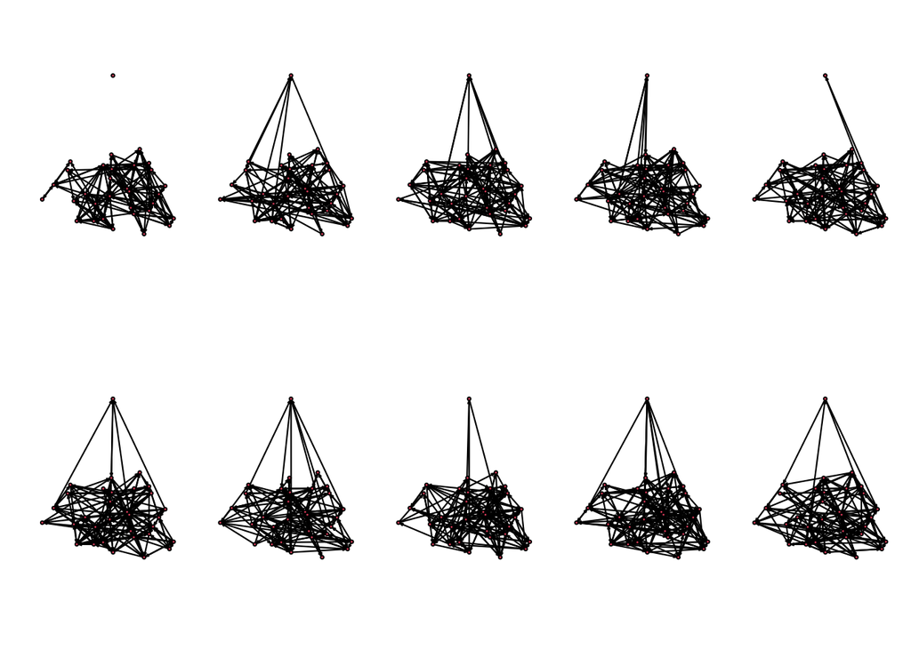

```r
par(mfrow=c(2,5),# want 2 by 5 panels
    oma = c(0,1,0,0) + 0.1,# custom outer margins
    mar = c(1,0,0,0) + 0.1)# custom inner margins
plot(as.network(tmp4),# observed network at t4
     coord=coordin) # observed network
invisible(# need to supress printing to consol
  apply(mySimNets[1:9,,],# for the first 9 networks in array
      1,# along first dimenstion, apply the following function
      function(x)
        plot(as.network(x),coord=coordin) ) )
```

Compare the *observed* number of reciprocated dyads to the *simulated* number of reciprocated dyads

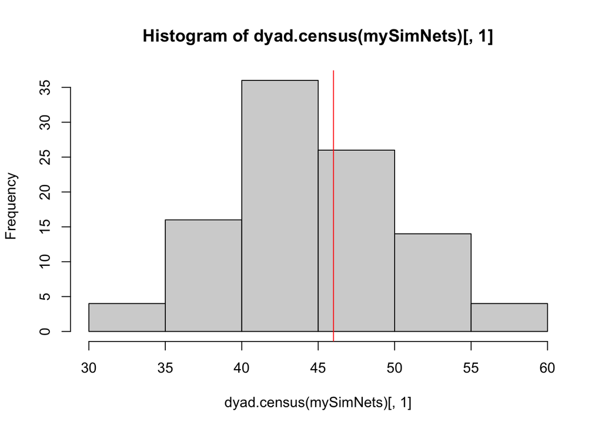

```r
hist( dyad.census(mySimNets)[,1])
abline(v = dyad.census(tmp4)[1], col='red')
```

> With an actor preference of 1.26 for having their ties reicprocated we reproduce the reciprocity

What about the triad cencus? Check the first 9

```r
triad.census(tmp4)# observed
triad.census(mySimNets[1:9,,])# first 9 simulated networks
```

Look at the distributions for **transitive** triads and **dense** triads

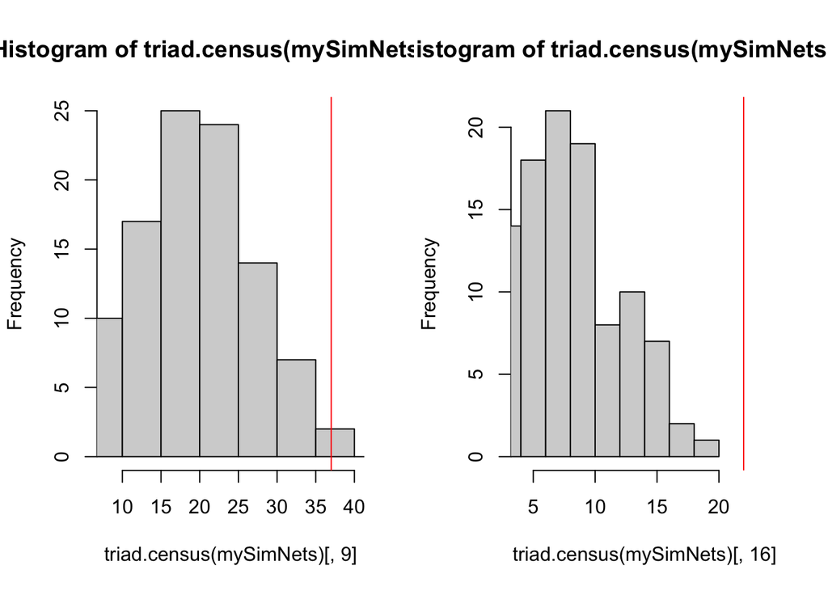

```r
par(mfrow=c(1,2))
hist( triad.census(mySimNets)[,9], xlim=c(8,40))# column 9 is 030T
abline(v = triad.census(tmp4)[9], col='red')
hist( triad.census(mySimNets)[,16], xlim=c(4,24))# column 16 is 300
abline(v = triad.census(tmp4)[16], col='red')
```

> A prefence for reciprocity is not enough to explain why reciprocated dyads hang together in triangles or why there are so many transitive triads

# Triangle model

Add another **positive** parameter $\beta_t$ for the preference for closing open triads.

```r
myeff <- includeEffects(myeff, recip,include=TRUE) # add the effect reciprocated ties
myeff <- includeEffects(myeff, transTrip,include=TRUE)
myeff$initialValue[myeff$shortName=='Rate'] <- 7.0959
myeff$initialValue[myeff$shortName=='density'][1] <- -1.6468
myeff$initialValue[myeff$shortName=='recip'][1] <- 0.8932
myeff$initialValue[myeff$shortName=='transTrip'][1] <- 0.2772
```

## Simulate

Set up the algorithm

```r
sim_model  <-  sienaAlgorithmCreate(
  projname = 'sim_model',
  cond = FALSE,
  useStdInits = FALSE,
  nsub = 0 ,
  n3 = 100,
  simOnly = TRUE)
```

Run simulation

```r
sim_ans <- siena07( sim_model, data = mydata,
                    effects = myeff,
                    returnDeps = TRUE, batch=TRUE )
```

Reshape and extract networks:

```r
mySimNets <- reshapeRSienaDeps(sim_ans,n)
```

What about the triad cencus? Check the first 9

```r
triad.census(tmp4)# observed
triad.census(mySimNets[1:9,,])# first 9 simulated networks
```

Look at the distributions for **transitive** triads and **dense** triads

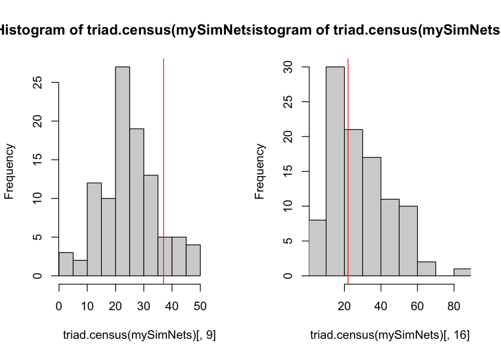

```r
par(mfrow=c(1,2))
hist( triad.census(mySimNets)[,9], xlim=c(2,55))# column 9 is 030T
abline(v = triad.census(tmp4)[9], col='red')
hist( triad.census(mySimNets)[,16], xlim=c(4,86))# column 16 is 300
abline(v = triad.census(tmp4)[16], col='red')
```

> Having preferences for reciprocated ties and transitive ties seem to explain ‘most’ of the structure

# Estimate SAOMs

How did I pick the numbers

- $\beta_d=-1.6468$
- $\beta_r= 0.8932$
- $\beta_t=0.2772$

Manually, you could

1. pick values $\beta_d^{\ast}$, $\beta_r^{\ast}$, and $\beta_t^{\ast}$
2. simulate lots of networks, and
3. adjust the parameters, so that
- increase (decrease) $\beta_d^{\ast}$ if density is too low (high)
- increase (decrease) $\beta_r^{\ast}$ if reciprocity is too low (high)
- increase (decrease) $\beta_t^{\ast}$ if transitivity is too low (high)
4. repeat

Luckily, we have an algorithm (stochastic approximation) for automating this

## Defining model

We define the model in the same way as when we simulated data

```r
myeff <- getEffects(mydata)# We already have our effects, but let's start from scratch
myeff <- includeEffects(myeff, recip,include=TRUE) # add the effect reciprocated ties (it is alredy include by DEFAULT though)
myeff <- includeEffects(myeff, transTrip,include=TRUE)# we want to estimate the trasitivity effect
```

Set up the algorithm with **default values** (`siena07` will assume you want to estimate)

```r
est_model  <-  sienaAlgorithmCreate(
  projname = 'est_model',
  n3 = 1000,# number of simulations in Phase 3 (default *is* 1000)
  simOnly = FALSE,# default *is* FALSE
  cond = FALSE,
  useStdInits = FALSE)
```

**Estimate!**

```r
est_ans <-siena07(est_model,# algorithm object
                  data = mydata, # the data object we created earlier
                  effects = myeff,# same effects as in simulation
                  returnDeps = TRUE,
                  batch=TRUE)
```

Estimation gives us an ANOVA table with - Parameter (point) estimates - Standard errors of estimates - Convergence statistis

```r
summary( est_ans )
```

```
## Estimates, standard errors and convergence t-ratios
##
##                                       Estimate   Standard   Convergence
##                                                    Error      t-ratio
##   1. rate basic rate parameter mynet1  7.0509  ( 0.9181   )   -0.0532
##   2. eval outdegree (density)         -1.6379  ( 0.1319   )    0.0302
##   3. eval reciprocity                  0.8899  ( 0.2044   )   -0.0128
##   4. eval transitive triplets          0.2742  ( 0.0451   )    0.0164
##
## Overall maximum convergence ratio:    0.1320
##
##
## Total of 2027 iteration steps.
##
## Covariance matrix of estimates (correlations below diagonal)
##
##        0.843        0.004        0.008       -0.009
##        0.037        0.017       -0.008       -0.004
##        0.041       -0.284        0.042       -0.002
##       -0.213       -0.658       -0.230        0.002
##
## Derivative matrix of expected statistics X by parameters:
##
##       11.609        5.273        4.237       52.864
##       77.869      229.555      153.898     1256.985
##       22.547       79.098       88.739      492.411
##      209.821      654.626      513.492     4861.125
##
## Covariance matrix of X (correlations below diagonal):
##
##      124.021      119.794       83.801      821.851
##        0.571      355.204      261.936     2242.861
##        0.481        0.888      244.765     1807.586
##        0.566        0.912        0.886    17019.156
```

> These estimates look very much like the numbers that I picked arbitrarily - what makes these better

The **observed statistics** that we want to ‘hit’ on average are

```r
est_ans$targets
```

```
## [1] 125 175  92 431
## attr(,"fromData")
## [1] TRUE
```

```r
# the same as sim_ans$targets
```

The simulated statistics for the parameters **from the estimation** are

```r
colMeans(est_ans$sf2)
```

```
##         [,1]    [,2] [,3]    [,4]
## [1,] 124.407 175.569 91.8 433.133
```

```r
# also provided in:
# est_ans$estMeans
```

The simulated statistics for the parameters **from the simulation** are

```r
sim_ans$estMeans
```

```
## [1] 125.56391 175.61942  93.60692 452.24754
## attr(,"fromData")
## [1] TRUE
```

We can calculate *within how many standard deviation units* of the **targets** we are for each statistic
$$\frac{\bar{z}_k-z_{obs}}{sd(z_k)}$$
The deviations using the estimates from estimation:

```r
(colMeans(est_ans$sf2)-est_ans$targets)/sqrt(diag(var(est_ans$sf2[,1,])))
```

```
##             [,1]       [,2]        [,3]       [,4]
## [1,] -0.05324838 0.03019069 -0.01278367 0.01635015
## attr(,"fromData")
## [1] TRUE
```

```r
# Also provided in:
# est_ans$tstat
```

For estimates from simulation:

```r
(colMeans(sim_ans$sf2)-sim_ans$targets)/sqrt(diag(var(sim_ans$sf2[,1,])))
```

As a quick illustration, we can see when we set rate, density, and reciprocity to the estimated values

```r
myeff$initialValue[myeff$shortName=='Rate'] <- est_ans$theta[1]
myeff$initialValue[myeff$shortName=='density'][1] <- est_ans$theta[2]
myeff$initialValue[myeff$shortName=='recip'][1] <-est_ans$theta[3]
```

*but* pick another value for transitivity:

```r
myeff$initialValue[myeff$shortName=='transTrip'][1] <- 0.1
```

and then, simulate!

```r
sim_model  <-  sienaAlgorithmCreate(
  projname = 'sim_model',
  cond = FALSE,
  useStdInits = FALSE,
  nsub = 0 ,
  n3 = 1000,
  simOnly = TRUE)
```

```r
sim_ans <- siena07( sim_model, data = mydata,
                    effects = myeff,
                    returnDeps = TRUE, batch=TRUE )
```

Calculate the scaled difference between the average statistics and the observed statistics again

```r
(colMeans(sim_ans$sf2)-sim_ans$targets)/sqrt(diag(var(sim_ans$sf2[,1,])))
```

The everage simulated statistics:

```r
sim_ans$estMeans
```

```r
sim_ans$targets
```

> Decreasing the transitivity parameter results in networks having too few transitive triads

# Convergence check

In general, we say that the estimation has converged and estimates can be estimated if

1. Convergence t-ratios $| t_{conv} | < 0.1$, and
2. Overall convergence ration less than $0.25$

## Summary of estimation

The aim of the estimation algorithm is to find estimates $\hat{\theta}$, such that
$$\underbrace{E_{\hat{\theta}}\{ Z[X(t_1)] \mid
X(t_0)=x_{obs}(t_0)\}}_{\text{'average'
statistics}}=Z[x_{obs}(t_1)]$$
The stochastic approximation algorithm in `siena07` solves this equation computationally in three **Phases**:

You may notice that the difference that is minimised in this algoritm is *not* $\bar{z}-z_{obs}$. Only **one** network is simulated in each interation - but it works (the other way also works but is less efficient)

# Standard errors

The second column in the ANOVA table contains the *nominal* **standard errors**, i.e. the approximate standard deviations of the estimators of the $\theta$’s. Typically, these are used for standard hypothesis tests:

For effect/parameter $k$, test
$$H_0:\beta_k=\beta_{k,0}=0$$
against
$$H_0:\beta_k\neq 0$$
The test statistic
$$\frac{\hat{\beta}_k-\beta_{k,0} }{sd(\hat{\beta}_k)}=\frac{\hat{\beta}_k
}{sd(\hat{\beta}_k)}\approx \frac{\hat{\beta}_k }{se(\hat{\beta}_k)},$$
is approximately normally distributed $N(0,1)$, if $H_0$ is true.

Given the number of assumptions and approximations we need to make, I would advice that we stick to testing on the nominal 5% level, and reject $H_0$ when the test statistic is greater than $2$ in absolute value.

## Test of simple model

In the simple model we estimated, let us test $H_0:\beta_t=0$. The observed test statistic

```r
est_ans$theta[4]/est_ans$se[4]
```

```
## [1] 6.07979
```

is considerably larger than 2, and we can reject the null-hypothesis that the true value of the transitivity parameter is $0$.

## Score-type test

Intuitively, we could also test if we ‘need’ $\beta_t$, by estimating the model with $\beta_t=0$, and check the convergence t-statistic. You can do this yourself now!

# Testing attribute

There are many different types of covariates

| Type | RSiena type |
| --- | --- |
| Constant monadic covariates | `coCovar` |
| Changing monadic covariates | `varCovar` |
| Constant dyadic covariate | `coDyadCovar` |
| Changing dyadic covariate | `varDyadCovar` |
| Changing (covariate) network | `sienaDependent` |

The usual nomenclauture for measurement scales, and the distinction between metric and non-metric variables, applies.

# Model with attributes

The adjacency matrices `s501`, `s502`, and `s503`, for the so-called s-50 dataset, the network of 50 girls, are also available with `RSiena`. For a full description of this dataset see `?s50` or http://www.stats.ox.ac.uk/~snijders/siena/s50_data.htm

## Rename adjacency matrices

For clarity, we rename the adjacency matrices

```r
friend.data.w1 <- s501
friend.data.w2 <- s502
friend.data.w3 <- s503
```

Note that we have *three* (3) waves.

Among the many monadic covariates are ‘smoking’ and ‘drinking’:

```r
drink <- s50a
smoke <- s50s
```

Here, each variable had its own $n \times 3$ data matrix, one observation for each individual and each time-point

```r
head(smoke)
```

We are going to test
$$H_0: \text{smokers have as many friends as non-smokers}$$
Against an alternative hypothesis stating that there is a difference. We will interpret this as “sending as many ties” and “receiving as many ties” as non-smokers.

[figure not shown]

Pogues

## Formatting covariates

We will use smoking at $t_0$ as our explanatory variable and define ‘smoking’ as a value of 2 or 3.

```r
smoke1.matrix <- as.numeric( smoke[,1]>1 )
table(smoke1.matrix, useNA='always')
```

To tell RSiena how to use this variable, we format it

```r
smoke1 <- coCovar( smoke1.matrix )
```

Print to screen to see how R has interpreted the variable

```r
smoke1
```

## Format DP

Format the dependent network variable as before:

```r
friendshipData <- array( c( friend.data.w1,
                            friend.data.w2,
                            friend.data.w3 ),
                         dim = c( 50, 50, 3 ) )
friendship <- sienaDependent(friendshipData)
```

## sienaDataCreate

Using `sienaDataCreate`, we give `RSiena` the oppotunity to figure out how data are structured and what types of effects can be calculated from it

```r
s50data <- sienaDataCreate( friendship, smoke1)
```

## getEffects

Since we have both a network as well as monadic covariates, we will have more effects avaialble to us that previously

```r
s50.effects <- getEffects(s50data)
```

### Sender effect

For testing our hypothesis we want a statistic that corresponds to
$$v_i x_{ij}$$
for each tie-variable, and where $v_i$ is one or zero according to whether $i$ is a smoker or not, respectively. This is the sender effect

```r
s50.effects <- includeEffects( s50.effects,# we "add and effect" to our effects object
                               egoX,# the shortname here evokes that variable for 'ego' affects decision
                               interaction1 = "smoke1" # the variable we want to interact the DV with
                               )
```

### Receiver effect

Next, we want a statistic that corresponds to
$$v_j x_{ij}$$
so that if the corresponding parameter is positive, then actors are more likely to form (maintain) ties to actors $j$ that have $v_j=1$, i.e. are smokers

```r
s50.effects <- includeEffects( s50.effects,
                               altX,# the shortname here evokes that variable for 'alter' affects decision of ego
                               interaction1 = "smoke1" # the variable we want to interact the DV with
                               )
```

## Transitivity

For the vanDeBunt dataset, we saw that triadic closure was important. We can chose to include it because we believe that it is important but also as a control for our hypothesised effects

```r
s50.effects <- includeEffects(s50.effects,# We "add and effect" to s50.effects
                              transTrip,# shortname of the effect
                              include=TRUE)
```

## Specified model

Our specified model is

```r
s50.effects
```

```
##   effectName                          include fix   test  initialValue parm
## 1 constant friendship rate (period 1) TRUE    FALSE FALSE    4.69604   0
## 2 constant friendship rate (period 2) TRUE    FALSE FALSE    4.32885   0
## 3 outdegree (density)                 TRUE    FALSE FALSE   -1.46770   0
## 4 reciprocity                         TRUE    FALSE FALSE    0.00000   0
## 5 transitive triplets                 TRUE    FALSE FALSE    0.00000   0
## 6 smoke1 alter                        TRUE    FALSE FALSE    0.00000   0
## 7 smoke1 ego                          TRUE    FALSE FALSE    0.00000   0
```

## sienaAlgorithmCreate

Specify the simulation settings

```r
s50algorithm.simple <- sienaAlgorithmCreate( projname = 's50_simple' )# We are only using defaults
```

## Estimate

Estimating the model with default settings is simply a callt to siena07

```r
s50.simple.ans <- siena07( s50algorithm.simple,# estimation settings
                  data = s50data,# data object that knows DV and IV
                  effects = s50.effects,# the effects we specified
                  batch = TRUE,
                  returnDeps = TRUE )
```

## Results

Print the results to screen

```r
summary( s50.simple.ans )
```

```
## Estimates, standard errors and convergence t-ratios
##
##                                    Estimate   Standard   Convergence
##                                                 Error      t-ratio
##
## Rate parameters:
##   0.1      Rate parameter period 1  6.4839  ( 1.0919   )
##   0.2      Rate parameter period 2  5.2511  ( 0.9410   )
##
## Other parameters:
##   1.  eval outdegree (density)     -2.6851  ( 0.1189   )   -0.0008
##   2.  eval reciprocity              2.4623  ( 0.1949   )    0.0095
##   3.  eval transitive triplets      0.6230  ( 0.0804   )    0.0282
##   4.  eval smoke1 alter            -0.0174  ( 0.1662   )   -0.0526
##   5.  eval smoke1 ego               0.0601  ( 0.1869   )   -0.0850
##
## Overall maximum convergence ratio:    0.0999
##
##
## Total of 2084 iteration steps.
##
## Covariance matrix of estimates (correlations below diagonal)
##
##        0.014       -0.014       -0.005        0.001       -0.001
##       -0.584        0.038       -0.002        0.000        0.001
##       -0.522       -0.117        0.006       -0.001        0.000
##        0.067        0.009       -0.077        0.028       -0.009
##       -0.033        0.035       -0.018       -0.282        0.035
##
## Derivative matrix of expected statistics X by parameters:
##
##      326.374      259.474      575.741       -2.125        0.466
##      146.432      154.773      290.313       -0.806       -0.432
##      381.630      345.734     1213.550        6.629        8.736
##       -2.317       -2.120        0.230       44.925       23.344
##       -0.292       -1.663      -10.641       24.789       40.064
##
## Covariance matrix of X (correlations below diagonal):
##
##      518.538      453.445     1237.596       -0.903       -0.431
##        0.934      454.722     1210.613       -0.405       -0.543
##        0.800        0.836     4616.297        0.153       -0.206
##       -0.005       -0.003        0.000       57.221       42.538
##       -0.003       -0.003        0.000        0.761       54.570
```

> Are all convergence statistics are less than 0.1 in absolute value? If so we can test our hypothesis - do we reject our $H_0$?

# Adding homophily

To account for (test) possible assortativity on smoking, we add the homophily effect:

```r
s50.effects <- includeEffects( s50.effects,# we "add and effect" to our effects object
                               sameX,# the shortname
                               interaction1 = "smoke1" # the variable we want to interact the DV with
                               )
s50.effects <- includeEffects( s50.effects,egoXaltX,interaction1 = "smoke1",include=FALSE)
```

## Re-estimate

```r
s50.hom.ans <- siena07( s50algorithm.simple,# estimation settings
                  data = s50data,# data object that knows DV and IV
                  effects = s50.effects,# the effects we specified
                  batch = TRUE,
                  returnDeps = TRUE )
```

## Results

Print the results to screen

```r
summary( s50.hom.ans )
```

```
## Estimates, standard errors and convergence t-ratios
##
##                                    Estimate   Standard   Convergence
##                                                 Error      t-ratio
##
## Rate parameters:
##   0.1      Rate parameter period 1  6.4354  ( 1.0763   )
##   0.2      Rate parameter period 2  5.2489  ( 0.8845   )
##
## Other parameters:
##   1.  eval outdegree (density)     -2.8916  ( 0.1760   )    0.0235
##   2.  eval reciprocity              2.4269  ( 0.1963   )    0.0021
##   3.  eval transitive triplets      0.6112  ( 0.0795   )   -0.0082
##   4.  eval smoke1 alter             0.0806  ( 0.1776   )   -0.0905
##   5.  eval smoke1 ego               0.1626  ( 0.1904   )   -0.0049
##   6.  eval same smoke1              0.3228  ( 0.1732   )    0.0062
##
## Overall maximum convergence ratio:    0.1763
##
##
## Total of 2089 iteration steps.
##
## Covariance matrix of estimates (correlations below diagonal)
##
##        0.031       -0.015       -0.004       -0.006       -0.005       -0.023
##       -0.436        0.039       -0.002        0.000        0.002        0.001
##       -0.285       -0.138        0.006       -0.001       -0.001        0.000
##       -0.204       -0.007       -0.045        0.032       -0.009        0.010
##       -0.147        0.053       -0.073       -0.252        0.036        0.007
##       -0.741        0.043       -0.019        0.312        0.209        0.030
##
## Derivative matrix of expected statistics X by parameters:
##
##      296.037      230.280      497.384       -1.004       -0.616      226.597
##      135.326      142.737      270.270        1.650        1.372      102.586
##      334.765      300.380     1093.016       13.374       14.181      250.495
##        5.140        6.238       20.834       46.699       28.369      -15.523
##        4.057        3.483       19.377       30.036       43.513      -15.285
##      220.918      174.334      377.737      -20.018      -18.026      218.489
##
## Covariance matrix of X (correlations below diagonal):
##
##      495.845      423.201     1159.623       12.547       12.233      378.536
##        0.931      416.667     1115.580       16.084       15.063      326.009
##        0.800        0.840     4237.838       58.236       58.438      885.002
##        0.071        0.099        0.113       63.144       51.891      -16.760
##        0.070        0.094        0.114        0.831       61.817      -17.509
##        0.910        0.855        0.728       -0.113       -0.119      349.176
```

```r
s50.hom.ans.2 <- siena07( s50algorithm.simple,# estimation settings
                  data = s50data,# data object that knows DV and IV
                  effects = s50.effects,# the effects we specified
                  batch = TRUE,
                  returnDeps = TRUE,
                  prevAns = s50.hom.ans)
```

## Interpretation

If

1. Convergence t-ratios $| t_{conv} | < 0.1$, and
2. Overall convergence ration less than $0.25$

we can test our hypothesis, controlling for possible assortativity/homophily

> What about homophily on smoking - do smokers befried other smokers?

# Goodness-of-fit (GOF)

How do we know if the model is any good?

> You may simulate from the model to see if it replicates data

## Built in GOF routines

If you estimate a model with `siena07` and set `returnDeps=TRUE`, the answer object returns the simulations from Phase 3. Let us try with the model for `s50` from `CHDH-SNA-3.Rmd`.

### Setting up s50

```r
friend.data.w1 <- s501# s50 wave 1
friend.data.w2 <- s502# s50 wave 2
friend.data.w3 <- s503# s50 wave 3

smoke <- s50s# s50 smoking wave 1,2, and 3
smoke1.matrix <- as.numeric( smoke[,1]>1 )# dichotomise
smoke1 <- coCovar( smoke1.matrix )# format as constant covariate
friendshipData <- array( c( friend.data.w1,
                            friend.data.w2,
                            friend.data.w3 ),
                         dim = c( 50, 50, 3 ) )# paste together adjacency matrices in array
friendship <- sienaDependent(friendshipData)# designate network as dependent variable
s50data <- sienaDataCreate( friendship, smoke1) # create the siena data object
s50.effects <- getEffects(s50data) # create an effects structure
s50.effects <- includeEffects(s50.effects,# We "add an effect" to s50.effects
                              transTrip,# shortname of the effect
                              include=TRUE)
s50.effects <- includeEffects( s50.effects,# we "add an effect" to our effects object
                               egoX,# the shortname here evokes that variable for 'ego' affects decision
                               interaction1 = "smoke1" # the variable we want to interact the DV with
                               )
s50.effects <- includeEffects( s50.effects,
                               altX,# the shortname here evokes that variable for 'alter' affects decision of ego
                               interaction1 = "smoke1" # the variable we want to interact the DV with
                               )
s50.effects <- includeEffects( s50.effects,egoXaltX,interaction1 = "smoke1",include=TRUE)# this is homophily on smoking
s50algorithm.simple <- sienaAlgorithmCreate( projname = 's50_simple' )# We are only using defaults
```

Now estimate

```r
s50.hom.ans <- siena07( s50algorithm.simple,# estimation settings
                  data = s50data,# data object that knows DV and IV
                  effects = s50.effects,# the effects we specified
                  batch = TRUE,
                  returnDeps = TRUE )# IMPORTANT: we want to have access to networks simulated in Phase 3
```

[output not shown]

[output cut: 39 more lines]

[output not shown]

```r
#### REESTIMATE:
s50.hom.ans <- siena07( s50algorithm.simple,# estimation settings
                         data = s50data,# data object that knows DV and IV
                         effects = s50.effects,# the effects we specified
                         batch = TRUE,
                         returnDeps = TRUE ,prevAns = s50.hom.ans)
```

[output not shown]

[output cut: 22 more lines]

[output not shown]

## Fit of network measures

To test if the model replicates data well, we have to define what we want to look at.

The in- and out-degree distributions are already provided in the GOF routine

```r
(gofi0 <- sienaGOF(s50.hom.ans, IndegreeDistribution, verbose=TRUE, join=TRUE,
     varName="friendship"))
```

```
## Detected 1000 iterations and 1 group.
```

```
## Calculating auxiliary statistics for periods  1 2 .
```

```
##   Period 1
```

[output not shown]

```
##   Period 2
```

[output not shown]

```
## Siena Goodness of Fit ( IndegreeDistribution ), all periods
## =====
## Monte Carlo Mahalanobis distance test p-value:  0.484
## -----
## One tailed test used  (i.e. estimated probability of greater distance than observation).
## -----
## Calculated joint MHD = ( 10.32 ) for current model.
```

```r
(gofo0 <- sienaGOF(s50.hom.ans, OutdegreeDistribution, verbose=TRUE, join=TRUE,
     levls=c(0:10,15,20),varName="friendship"))
```

```
## Detected 1000 iterations and 1 group.
```

```
## Calculating auxiliary statistics for periods  1 2 .
```

```
##   Period 1
```

[output not shown]

```
##   Period 2
```

[output not shown]

```
## Siena Goodness of Fit ( OutdegreeDistribution ), all periods
## =====
## Monte Carlo Mahalanobis distance test p-value:  0.46
## **Note: Only 11 statistics are necessary in the auxiliary function.
## -----
## One tailed test used  (i.e. estimated probability of greater distance than observation).
## -----
## Calculated joint MHD = ( 17.39 ) for current model.
```

```r
(gof0.tc <- sienaGOF(s50.hom.ans, TriadCensus, verbose=TRUE, join=TRUE,
     varName="friendship"))
```

```
## Detected 1000 iterations and 1 group.
```

```
## Calculating auxiliary statistics for periods  1 2 .
```

```
##   Period 1
```

[output not shown]

```
##   Period 2
```

[output not shown]

```
## Siena Goodness of Fit ( TriadCensus ), all periods
## =====
## Monte Carlo Mahalanobis distance test p-value:  0.001
## **Note: Only 15 statistics are necessary in the auxiliary function.
## -----
## One tailed test used  (i.e. estimated probability of greater distance than observation).
## -----
## Calculated joint MHD = ( 70.68 ) for current model.
```

## Inspecting GOF distributions

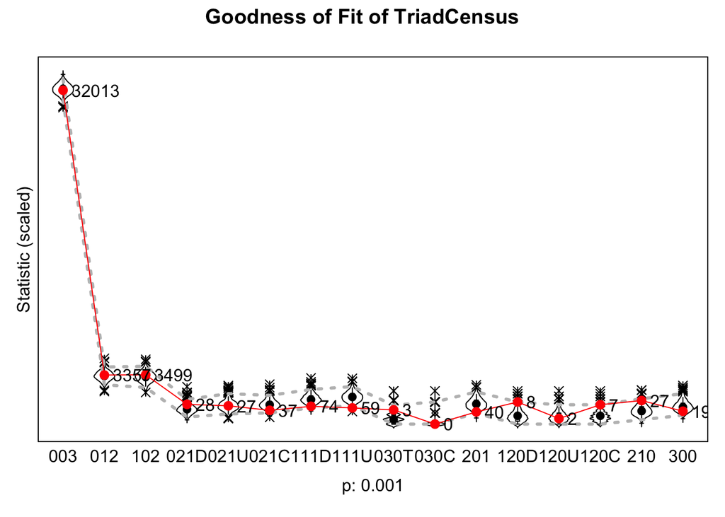

```r
plot( gof0.tc ,scale=TRUE)
```

# Dependent behaviour

We are now going to use drinking alcohol as **both** a changing covariate **and** a dependent variable.

## sienaDependent

Since the alcohol variable is a dependent variable, we use `sienaDependent` to format it (print to screen to get a quick view of the information stored)

```r
drink <- s50a
drinking <- sienaDependent( drink, type = "behavior" )
```

## sienaDataCreate

We now have a dataset with two dependent variables so we need to create a new siena data object using `sienaDataCreate`:

```r
s50data.infl <- sienaDataCreate( friendship, smoke1, drinking )
```

## getEffects

```r
s50.effects.infl <- getEffects(s50data.infl)
```

## As covariate

```r
s50.effects.infl <- includeEffects( s50.effects.infl,# again, 'adding' to the effects
                                    egoX,# sender effect for alcohol
                                    #egoSqX,# non-linear sender effect
                                    altX,# receiver effect for alcohol
                                   # altSqX,# non-linear receiver effect
                                   # diffSqX,# squared difference of alcohol ego and alcohol alter
                                   egoXaltX,
                                    name = 'friendship',
                                    interaction1 = "drinking" # DV works the same as an IV on another DV
                                   # include =FALSE
                                    )
```

```
##   effectNumber effectName                    shortName include fix   test
## 1 424          drinking alter                altX      TRUE    FALSE FALSE
## 2 439          drinking ego                  egoX      TRUE    FALSE FALSE
## 3 574          drinking ego x drinking alter egoXaltX  TRUE    FALSE FALSE
##   initialValue parm
## 1          0   0
## 2          0   0
## 3          0   0
```

## As a DV

The dependent variable `drinking` can act as a dependent variable for other variables, including the other dependent variables.

```r
s50.effects.infl <- includeEffects( s50.effects.infl,# still augmenting effects structure
                                    avAlt,# this is the shortname for "average alter"
                                    name="drinking",# name: what is the dependent variable
                                    interaction1 = "friendship" # the network is now "independent" variable
                                    )
```

```
##   effectNumber effectName             shortName include fix   test
## 1 729          drinking average alter avAlt     TRUE    FALSE FALSE
##   initialValue parm
## 1          0   0
```

## Other effects

We use the same social selection effects for smoking, the sender effect

```r
s50.effects.infl <- includeEffects( s50.effects.infl,# we "add and effect" to our effects object
                               egoX,# the shortname here evokes that variable for 'ego' affects decision
                               interaction1 = "smoke1" # the variable we want to interact the DV with
                               )
```

and the receiver effect

```r
s50.effects.infl <- includeEffects( s50.effects.infl,
                               altX,# the shortname here evokes that variable for 'alter' affects decision of ego
                               interaction1 = "smoke1" # the variable we want to interact the DV with
                               )
```

and the homophily effect

```r
s50.effects.infl  <- includeEffects( s50.effects.infl ,# we "add and effect" to our effects object
                               egoXaltX,# the shortname
                               interaction1 = "smoke1" # the variable we want to interact the DV with
                               )
```

## Structural effects

We will use *two* (2) different transitivity effects

```r
s50.effects.infl <- includeEffects( s50.effects.infl, transTrip, transRecTrip )
```

```
##   effectNumber effectName                  shortName    include fix   test
## 1 23           transitive triplets         transTrip    TRUE    FALSE FALSE
## 2 35           transitive recipr. triplets transRecTrip TRUE    FALSE FALSE
##   initialValue parm
## 1          0   0
## 2          0   0
```

## Estimate

Set up estimation settings:

```r
s50.algo.infl<- sienaAlgorithmCreate( projname = 's50_infl' )
```

And we can estimate the model (it will take a little longer)

```r
s50.est.infl <- siena07( s50.algo.infl,
                         data = s50data.infl,
                         effects = s50.effects.infl,
                         batch = TRUE,
                         returnDeps = TRUE )
```

## Results

We view the ANOVA table as before:

```r
summary(s50.est.infl)
```

```
## Estimates, standard errors and convergence t-ratios
##
##                                                Estimate   Standard   Convergence
##                                                             Error      t-ratio
## Network Dynamics
##    1. rate constant friendship rate (period 1)  6.3214  ( 0.9762   )   -0.0287
##    2. rate constant friendship rate (period 2)  5.0602  ( 0.7713   )   -0.0634
##    3. eval outdegree (density)                 -2.8563  ( 0.1503   )   -0.0008
##    4. eval reciprocity                          2.7241  ( 0.2528   )    0.0151
##    5. eval transitive triplets                  0.8885  ( 0.1456   )    0.0265
##    6. eval transitive recipr. triplets         -0.5316  ( 0.2146   )    0.0355
##    7. eval smoke1 alter                        -0.0421  ( 0.2229   )    0.0260
##    8. eval smoke1 ego                          -0.0473  ( 0.2360   )   -0.0027
##    9. eval smoke1 ego x smoke1 alter            0.3188  ( 0.3523   )    0.0372
##   10. eval drinking alter                      -0.0593  ( 0.1101   )   -0.0210
##   11. eval drinking ego                         0.0247  ( 0.1168   )   -0.0050
##   12. eval drinking ego x drinking alter        0.1634  ( 0.0721   )    0.0074
##
## Behavior Dynamics
##   13. rate rate drinking (period 1)             1.3172  ( 0.3411   )    0.0245
##   14. rate rate drinking (period 2)             1.7518  ( 0.5397   )   -0.0164
##   15. eval drinking linear shape                0.4270  ( 0.2405   )    0.0332
##   16. eval drinking quadratic shape            -0.5791  ( 0.3421   )   -0.0667
##   17. eval drinking average alter               1.2347  ( 0.7986   )   -0.0295
##
## Overall maximum convergence ratio:    0.1631
##
##
## Total of 3263 iteration steps.
##
## Covariance matrix of estimates (correlations below diagonal)
##
##        0.953       -0.058        0.041       -0.021       -0.034        0.027       -0.020       -0.006        0.039        0.008        0.004       -0.004       -0.017        0.006       -0.013        0.036       -0.060
##       -0.077        0.595        0.002       -0.001       -0.003        0.005        0.007       -0.014       -0.009        0.002        0.003       -0.006        0.002       -0.016       -0.013        0.034       -0.061
##        0.276        0.019        0.023       -0.028       -0.015        0.017        0.001        0.003        0.003        0.001        0.000       -0.002        0.002       -0.008       -0.002        0.002       -0.003
##       -0.084       -0.004       -0.726        0.064        0.019       -0.033        0.001       -0.001       -0.004       -0.002        0.000        0.000       -0.002        0.007        0.000        0.002       -0.006
##       -0.241       -0.026       -0.667        0.517        0.021       -0.027        0.000       -0.002       -0.007        0.002       -0.002       -0.001        0.001        0.007       -0.002        0.003       -0.010
##        0.128        0.031        0.515       -0.614       -0.861        0.046        0.000        0.001        0.006       -0.003        0.005        0.000       -0.001       -0.005        0.006       -0.009        0.025
##       -0.090        0.038        0.035        0.009       -0.006       -0.008        0.050       -0.006       -0.013       -0.013        0.002       -0.001        0.006       -0.008        0.010       -0.012        0.029
##       -0.026       -0.076        0.079       -0.015       -0.067        0.018       -0.114        0.056       -0.013       -0.002       -0.013        0.001       -0.001       -0.015        0.003       -0.004        0.008
```

[output cut: 34 more lines]

```
##        0.373        0.262      563.920      442.473     1516.290     1181.782        4.902        6.124       46.822      -63.270      -38.125      350.496       -1.879        1.320       -0.703       22.132       23.229
##        0.285        0.184        0.919      411.354     1261.347     1049.494        2.934        5.096       38.272      -51.298      -36.898      287.899       -0.370        2.995        0.299       25.856       26.288
##        0.375        0.256        0.836        0.814     5836.306     4689.756       42.785       45.344      142.208      -86.094      -54.784     1044.825        3.622        8.743       16.329       81.074       70.871
##        0.350        0.236        0.793        0.824        0.978     3938.844       37.365       38.879      116.090      -69.061      -55.556      845.255        2.853        8.529       16.495       82.344       68.064
##       -0.075        0.039        0.024        0.017        0.064        0.068       75.676       62.397       21.592      156.593      139.693       48.585        1.750        0.259       11.778        2.118        4.322
##       -0.043        0.053        0.030        0.029        0.070        0.073        0.840       72.870       21.737      141.180      146.121       49.179        0.982       -0.600        9.424        1.934        5.301
##        0.143        0.117        0.417        0.400        0.394        0.392        0.526        0.539       22.306       32.319       35.470       66.572       -0.371       -0.447        1.589        9.756        9.743
##       -0.186        0.034       -0.110       -0.104       -0.046       -0.045        0.742        0.681        0.282      589.172      471.522      -16.493        5.726        2.096       55.788        1.840        7.853
##       -0.174        0.038       -0.069       -0.079       -0.031       -0.038        0.694        0.739        0.324        0.839      535.907        5.178        3.240       -0.512       45.144        1.706       12.362
##        0.202        0.213        0.475        0.456        0.440        0.433        0.180        0.185        0.453       -0.022        0.007      967.472      -12.587       -9.446      -15.882       93.640       49.225
##        0.041       -0.001       -0.018       -0.004        0.011        0.010        0.045        0.026       -0.018        0.053        0.031       -0.091       19.827        1.443       12.182       -2.567       -0.619
##       -0.003        0.009        0.012        0.031        0.024        0.028        0.006       -0.015       -0.020        0.018       -0.005       -0.063        0.067       23.078       13.735        1.584        3.620
##       -0.073        0.037       -0.003        0.002        0.022        0.027        0.141        0.115        0.035        0.240        0.204       -0.053        0.285        0.298       91.829        8.991       23.761
##        0.007        0.032        0.069        0.094        0.079        0.097        0.018        0.017        0.153        0.006        0.005        0.223       -0.043        0.024        0.070      182.214      113.006
##       -0.048        0.013        0.080        0.106        0.076        0.089        0.041        0.051        0.169        0.026        0.044        0.129       -0.011        0.062        0.203        0.684      149.636
```

Make a nicer listing of the results:

```r
siena.table(s50.est.infl, type="html", sig=TRUE)
```

```
## Results for s50.est.infl written to s50.est.infl.html .
```

# All effects

Let us explore more effects using the s50 data set.

## Data and model

Instead of using smoking as a constant covariate, we will define smoking as yet another dependent variable

```r
smoke <- s50s
```

Define dependent and independent variables

```r
# format the dependent variables:
friendshipData <- array( c( friend.data.w1,
                            friend.data.w2,
                            friend.data.w3 ),
                         dim = c( 50, 50, 3 ) )
friendship <- sienaDependent(friendshipData)
drinking <- sienaDependent( drink, type = "behavior" )
smoking <- sienaDependent( smoke, type = "behavior" )
s50.big.data <- sienaDataCreate( friendship, smoking, drinking )
# chose effects
s50.big.effs <- getEffects( s50.big.data )
```

## Effects

The effects avaiable to us are in the object `s50.big.effs`. Have a look!

The most important columns are:

| name | effectName | shortName | interaction1 | interaction2 | include | fix | test |
| --- | --- | --- | --- | --- | --- | --- | --- |
| Dependent variable that owns effect | description | what you use to define model | covariate 1 | covariate 2 | in model, T/F | T/F | T /F |

## Manual

The manual has a comprehensive list of possible effects

## Structural effects

Let us examine only the structural part of the previous model

```r
s50.big.effs <- includeEffects( s50.big.effs, transTrip, transRecTrip )
```

```
##   effectNumber effectName                  shortName    include fix   test
## 1 23           transitive triplets         transTrip    TRUE    FALSE FALSE
## 2 35           transitive recipr. triplets transRecTrip TRUE    FALSE FALSE
##   initialValue parm
## 1          0   0
## 2          0   0
```

Set up estimation settings:

```r
s50.algo.struc.1<- sienaAlgorithmCreate( projname = 's50_struc.1' )
```

And estimate

```r
s50.est.struc.1 <- siena07( s50.algo.struc.1,
                         data = s50.big.data ,
                         effects =s50.big.effs ,
                         batch = TRUE,
                         returnDeps = TRUE )
```

Check results

```r
summary( s50.est.struc.1 )
```

What happens if we substitute `transTies` for `transRecTrip`

```r
s50.big.effs <- includeEffects( s50.big.effs,transRecTrip,include=FALSE )
```

```
##   effectNumber effectName                  shortName    include fix   test
## 1 35           transitive recipr. triplets transRecTrip FALSE   FALSE FALSE
##   initialValue parm
## 1          0   0
```

```r
s50.big.effs <- includeEffects( s50.big.effs, transTies )
```

```
##   effectNumber effectName      shortName include fix   test  initialValue parm
## 1 46           transitive ties transTies TRUE    FALSE FALSE          0   0
```

And estimate

### GWESP

An alternative to having both `transTies` and `transTrip` is to use `GWESP`

```r
s50.big.effs <- includeEffects( s50.big.effs,transTies,transTrip,include=FALSE )
```

```
##   effectNumber effectName          shortName include fix   test  initialValue
## 1 23           transitive triplets transTrip FALSE   FALSE FALSE          0
## 2 46           transitive ties     transTies FALSE   FALSE FALSE          0
##   parm
## 1 0
## 2 0
```

```r
s50.big.effs <- includeEffects( s50.big.effs,gwespFF)
```

```
##   effectNumber effectName            shortName include fix   test  initialValue
## 1 56           GWESP I -> K -> J (#) gwespFF   TRUE    FALSE FALSE          0
##   parm
## 1 69
```

```r
s50.est.struc.4 <- siena07( s50.algo.struc.1,
                         data = s50.big.data ,
                         effects =s50.big.effs ,
                         batch = TRUE,
                         returnDeps = TRUE )
```

Check results

```r
summary( s50.est.struc.4 )
```

> What differences do we see between the different parametrizations?

## Selection effects

Looking at `s50.big.effs`, all effects with `name=friendship` and `interaction1=smoking` are social selection effects with respect to smoking.

```r
s50.effects.infl <- s50.big.effs
s50.effects.infl <- includeEffects( s50.effects.infl,# again, 'adding' to the effects
                                    egoX,# sender effect for alcohol
                                    egoSqX,# non-linear sender effect
                                    altX,# receiver effect for alcohol
                                    altSqX,# non-linear receiver effect
                                    diffSqX,# squared difference of alcohol ego and alcohol alter
                                    interaction1 = "drinking" # DV works the same as an IV on another DV
                                    )
```

```
##   effectNumber effectName             shortName include fix   test
## 1 427          drinking alter         altX      TRUE    FALSE FALSE
## 2 430          drinking squared alter altSqX    TRUE    FALSE FALSE
## 3 442          drinking ego           egoX      TRUE    FALSE FALSE
## 4 446          drinking squared ego   egoSqX    TRUE    FALSE FALSE
## 5 470          drinking diff. squared diffSqX   TRUE    FALSE FALSE
##   initialValue parm
## 1          0   0
## 2          0   0
## 3          0   0
## 4          0   0
## 5          0   0
```

```r
s50.effects.infl <- includeEffects( s50.effects.infl,# we "add and effect" to our effects object
                               egoX,# the shortname here evokes that variable for 'ego' affects decision
                               interaction1 = "smoking" # the variable we want to interact the DV with
                               )
```

```
##   effectNumber effectName  shortName include fix   test  initialValue parm
## 1 255          smoking ego egoX      TRUE    FALSE FALSE          0   0
```

> Change or add a covariate effect on friendship of smoking

Estimate!

```r
s50.est.infl.1 <- siena07( s50.algo.struc.1,
                         data = s50.big.data ,
                         effects =s50.effects.infl,
                         batch = TRUE,
                         returnDeps = TRUE )
```

Check results

```r
summary( s50.est.infl.1 )
```

## Influence effects

As before we specify

```r
s50.effects.infl.2 <- s50.big.effs
s50.effects.infl.2 <- includeEffects( s50.effects.infl.2,# still augmenting effects structure
                                    avAlt,# this is the shortname for "average alter"
                                    name="drinking",# name: what is the dependent variable
                                    interaction1 = "friendship" # the network is now "independent" variable
                                    )
```

```
##   effectNumber effectName             shortName include fix   test
## 1 933          drinking average alter avAlt     TRUE    FALSE FALSE
##   initialValue parm
## 1          0   0
```

But we can also add influence for `smoking` but let us try `totAlt` instead

```r
s50.effects.infl.2 <- includeEffects( s50.effects.infl.2,# still augmenting effects structure
                                    totAlt,# this is the shortname for "average alter"
                                    name="smoking",# name: what is the dependent variable
                                    interaction1 = "friendship" # the network is now "independent" variable
                                    )
```

```
##   effectNumber effectName          shortName include fix   test  initialValue
## 1 736          smoking total alter totAlt    TRUE    FALSE FALSE          0
##   parm
## 1 0
```

The dependent variable can also be predictors of each other. Smoking as DV

```r
s50.effects.infl.2 <- includeEffects( s50.effects.infl.2,# still augmenting effects structure
                                    effFrom,# the effect of 'interaction1' on smoking
                                      name="smoking",# name: what is the dependent variable
                                    interaction1 = "drinking"# drinking is now "independent" variable
                                    )
```

```
##   effectNumber effectName                    shortName include fix   test
## 1 777          smoking: effect from drinking effFrom   TRUE    FALSE FALSE
##   initialValue parm
## 1          0   0
```

Drinking as DV

```r
s50.effects.infl.2 <- includeEffects( s50.effects.infl.2,# still augmenting effects structure
                                    effFrom,# the effect of 'interaction1' on smoking
                                      name="drinking",# name: what is the dependent variable
                                    interaction1 = "smoking"# drinking is now "independent" variable
                                    )
```

```
##   effectNumber effectName                    shortName include fix   test
## 1 978          drinking: effect from smoking effFrom   TRUE    FALSE FALSE
##   initialValue parm
## 1          0   0
```

### Interaction multiple variables

The effect of the total similarity of an egos alters drinking on the smoking of ego (smoking tot. sim. (friendship) x alter’s drinking) requires two interactions

```r
s50.effects.infl.2 <- includeEffects( s50.effects.infl.2,# still augmenting effects structure
                                    totSimAltX,# the effect of 'interaction1' on smoking
                                    name="smoking",# name: what is the dependent variable
                                    interaction1 = "drinking",# drinking is now "independent" variable
                                    interaction2 = "friendship"
                                    )
```

```
##   effectNumber effectName                                         shortName
## 1 780          smoking: tot. sim. (friendship) x alter's drinking totSimAltX
##   include fix   test  initialValue parm
## 1 TRUE    FALSE FALSE          0   0
```

Estimate!

```r
s50.est.infl.2 <- siena07( s50.algo.struc.1,
                         data = s50.big.data ,
                         effects =s50.effects.infl.2,
                         batch = TRUE,
                         returnDeps = TRUE )
```

Check results

```r
summary( s50.est.infl.2 )
```

# More Goodness-of-fit (GOF)

## Built in GOF routines

### Score-type test

What if we want to test if we should include `totSimAltX` for `drinking`?

The we add the effect but set `test=TRUE` and `fix=TRUE`

```r
s50.effects.infl.3 <- s50.effects.infl.2
s50.effects.infl.3 <- includeEffects( s50.effects.infl.3,# still augmenting effects structure
                                    totSimAltX,# the effect of 'interaction1' on smoking
                                    name="drinking",# name: what is the dependent variable
                                    interaction1 = "smoking",# drinking is now "independent" variable
                                    interaction2 = "friendship" ,
                                    test=TRUE, fix=TRUE
                                    )
```

```
##   effectNumber effectName                                         shortName
## 1 981          drinking: tot. sim. (friendship) x alter's smoking totSimAltX
##   include fix  test initialValue parm
## 1 TRUE    TRUE TRUE          0   0
```

The parameter is now fixed to 0

Estimate the model with `totSimAltX` for drinking set to 0

Estimate!

```r
(s50.est.infl.3 <- siena07( s50.algo.struc.1,
                         data = s50.big.data ,
                         effects =s50.effects.infl.3,
                         batch = TRUE,
                         returnDeps = TRUE ))
```

We can now test
$$H_0: \beta_{totSimAltX}=0$$
against

$$H_1: \beta_{totSimAltX}\neq0$$

using a Score-type test:

```r
score.Test(s50.est.infl.3)
```

```
## Tested effects:
##  drinking: drinking: tot. sim. (friendship) x alter's smoking eval
## chi-squared = 2.83, d.f. = 1; one-sided Z = -1.68; two-sided p = 0.092.
```

> This test only uses the simulated statistics for the effect and there is no need to actually estimate the parameter

# Trouble shooting

## Convergence issues

What if my model does not converge?

If converge t-statistics are close to $0.1$ in absolute value, restart using `prevAns`

Assume that we did not have enough iterations in Phase 3 **and** only 2 subphases in Phase 2

```r
s50.algo.struc.short<- sienaAlgorithmCreate( projname = 's50_struc.1', n3 =50, nsub=2)
```

Estimate!

```r
(s50.est.infl.3 <- siena07( s50.algo.struc.short,
                         data = s50.big.data ,
                         effects =s50.effects.infl.2,
                         batch = TRUE,
                         returnDeps = TRUE ))
```